# Intro to sentiment analysis and NLP.

## What is sentiment analysis and NLP and whats the relation between them?

##### Think about the mounds of emails, texts, reviews, tweets, and more textual data that contain people’s opinions. Sentiment analysis occurs when we analyze this textual data to find meaningful patterns.

##### Natural language processing is broadly defined as using software to manipulate natural languages (speech, text,…). Sentiment analysis is one of the most important fields of NLP.

##### Examples in which sentiment analysis is used:

##### - Brand monitoring

##### - Policy making

##### - Market research

##### - Political Campaigns

### Analyzing Rick and Morty scripts

```r
library(readr)
library(tidyverse)
library(wordcloud)
library(tidytext)
library(textdata)
library(knitr)
library(stringr)
library(dplyr)
library(tm)
```

##### Loading Rick and Morty scripts and taking a glimpse

```r
data<- read.csv("RickAndMortyScripts.csv")

glimpse(data)
```

```
## Rows: 1,905
## Columns: 6
## $ index        <int> 0, 1, 2, 3, 4, 5, 6, 7, 8, 9, 10, 11, 12, 13, 14, 15, 16,…
## $ season.no.   <int> 1, 1, 1, 1, 1, 1, 1, 1, 1, 1, 1, 1, 1, 1, 1, 1, 1, 1, 1, …
## $ episode.no.  <int> 1, 1, 1, 1, 1, 1, 1, 1, 1, 1, 1, 1, 1, 1, 1, 1, 1, 1, 1, …
## $ episode.name <chr> "Pilot", "Pilot", "Pilot", "Pilot", "Pilot", "Pilot", "Pi…
## $ name         <chr> "Rick", "Morty", "Rick", "Morty", "Rick", "Morty", "Rick"…
## $ line         <chr> "Morty! You gotta come on. Jus'... you gotta come with me…
```

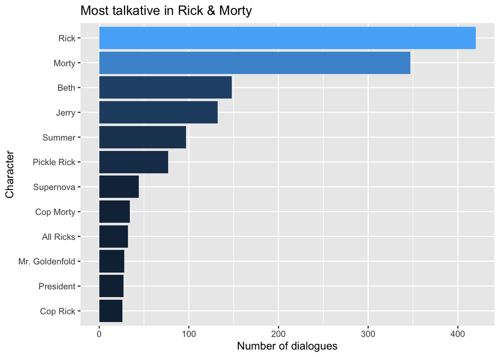

```r
# Top twelve characters with the most dialogues
data %>%
  # prepare the table
  count(name) %>%
  arrange(desc(n)) %>%
  slice(1:12) %>%

  # the plot
  ggplot(aes(x=reorder(name, n), y=n)) +
  geom_bar(stat="identity", aes(fill=n), show.legend=F,linetype=4)  +
  labs(x="Character", y="Number of dialogues", title="Most talkative in Rick & Morty") +
  coord_flip()
```

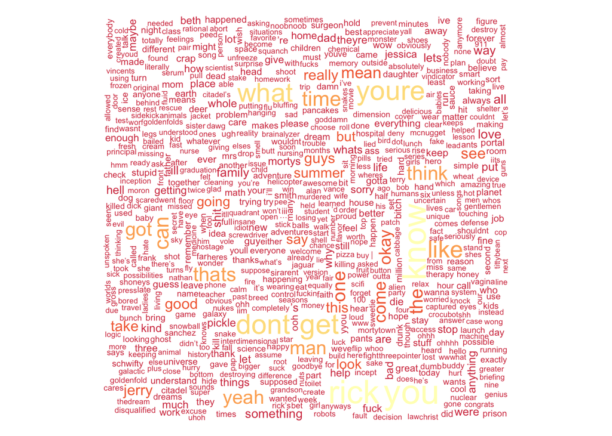

```r
wordcloud((data$line), size=1.6, minSize = 0.9,
          shape="square", fontFamily="arial",colors=brewer.pal(9, 'Spectral'))
```

### Lexicons

##### Text data is compared to lists associated with negative and positive words in the text. These lists are called lexicons and you can create your own or use a common one. For our purposes, we will use Bing,NRC, and Afinn.

### Tokens

##### When doing sentiment analysis, we often need to slice the text into different forms when tidying it. The most common form is to tokenize it by word.

```r
#get lexicon from package
bing <-get_sentiments("bing")
afinn <-get_sentiments("afinn")
nrc<- get_sentiments("nrc")

tokens <- data %>%
  mutate(line = as.character(data$line)) %>%
  unnest_tokens(word, line)

tokens %>% head(6) %>% select(name, word)
```

```
##   name  word
## 1 Rick morty
## 2 Rick   you
## 3 Rick gotta
## 4 Rick  come
## 5 Rick    on
## 6 Rick   jus
```

##### Bing lexicon classifies words into negative or positive

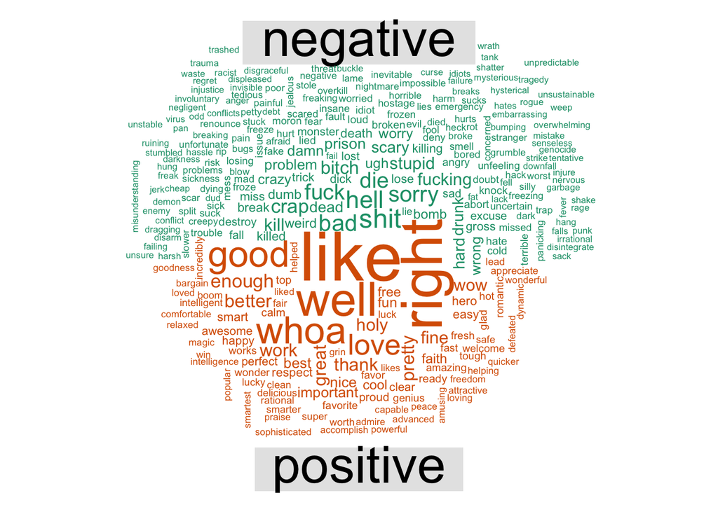

```r
library(reshape2)
tokens %>%
  # append the bing sentiment and prepare the data
  inner_join(bing, "word") %>%
  count(word, sentiment, sort=T) %>%
  acast(word ~ sentiment, value.var = "n", fill=0) %>%

  # wordcloud

  comparison.cloud()
```

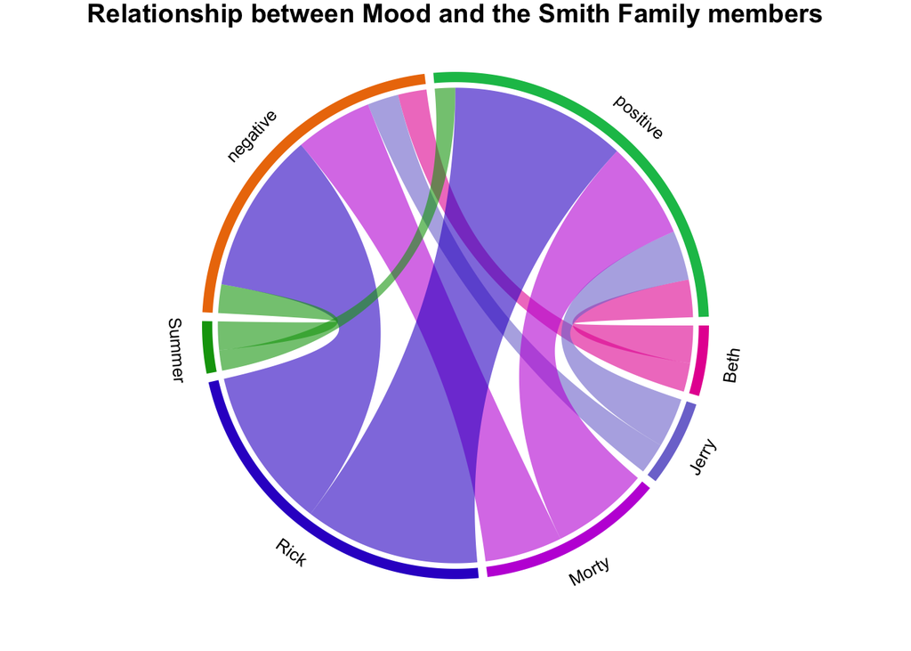

```r
to_plot <- tokens %>%

  # joing bing with data and filter it
  inner_join(bing, "word") %>%
  filter(name %in% c("Rick","Morty","Beth","Jerry","Summer")) %>%

  # sum number of words per sentiment and character
  count(sentiment, name) %>%
  group_by(name, sentiment) %>%
  summarise(sentiment_sum = sum(n)) %>%
  ungroup()

# The Chord Diagram
library(circlize)
circos.clear()
circos.par(gap.after = c(rep(2, length(unique(to_plot[[1]])) - 1), 10,
                         rep(2, length(unique(to_plot[[2]])) - 1), 10), gap.degree=2)

chordDiagram(to_plot, transparency = 0.4, annotationTrack = c("name", "grid"))

title("Relationship between Mood and the Smith Family members")
```

##### AFINN Lexicon

##### Ranks words from -5 to 5 with +5 being the most positive.

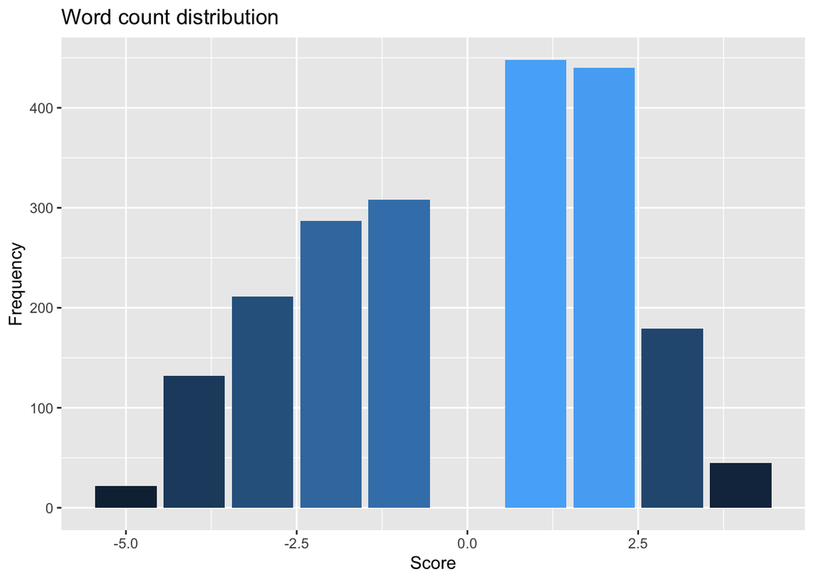

```r
tokens %>%
  # Count how many word per value
  inner_join(afinn, "word") %>%
  count(value, sort=T) %>%

  # Plot
  ggplot(aes(x=value, y=n)) +
  geom_bar(stat="identity", aes(fill=n), show.legend = F)+

  labs(x="Score", y="Frequency", title="Word count distribution")
```

##### Which words contributed the most to the score?

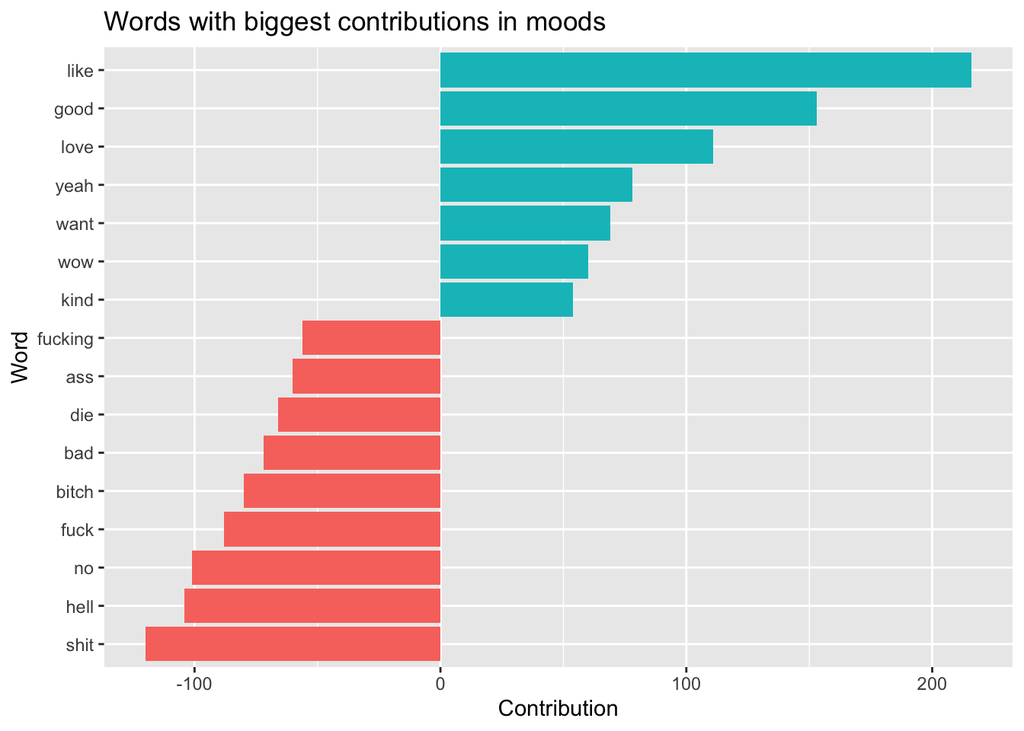

```r
tokens %>%
  # by word and value count number of occurences
  inner_join(afinn, "word") %>%
  count(word, value, sort=T) %>%
  mutate(contribution = n * value,
         sentiment = ifelse(contribution<=0, "Negative", "Positive")) %>%
  arrange(desc(abs(contribution))) %>%
  head(16) %>%

  # plot
  ggplot(aes(x=reorder(word, contribution), y=contribution, fill=sentiment)) +

  geom_col(aes(fill=sentiment), show.legend = F) +

  labs(x="Word", y="Contribution", title="Words with biggest contributions in moods") +
  coord_flip()
```

##### NRC Lexicon

##### The NRC Emotion Lexicon is a list of words and their associations with eight basic emotions (anger, fear, anticipation, trust, surprise, sadness, joy, and disgust) and two sentiments (negative and positive).

```r
sentiments <- tokens %>%
  inner_join(nrc, "word") %>%
  count(sentiment, sort=T)

sentiments
```

```
##       sentiment   n
## 1      positive 977
## 2      negative 901
## 3         trust 645
## 4  anticipation 591
## 5          fear 567
## 6           joy 494
## 7         anger 415
## 8       sadness 414
## 9       disgust 312
## 10     surprise 266
```

##### What’s the overall sentiment like?

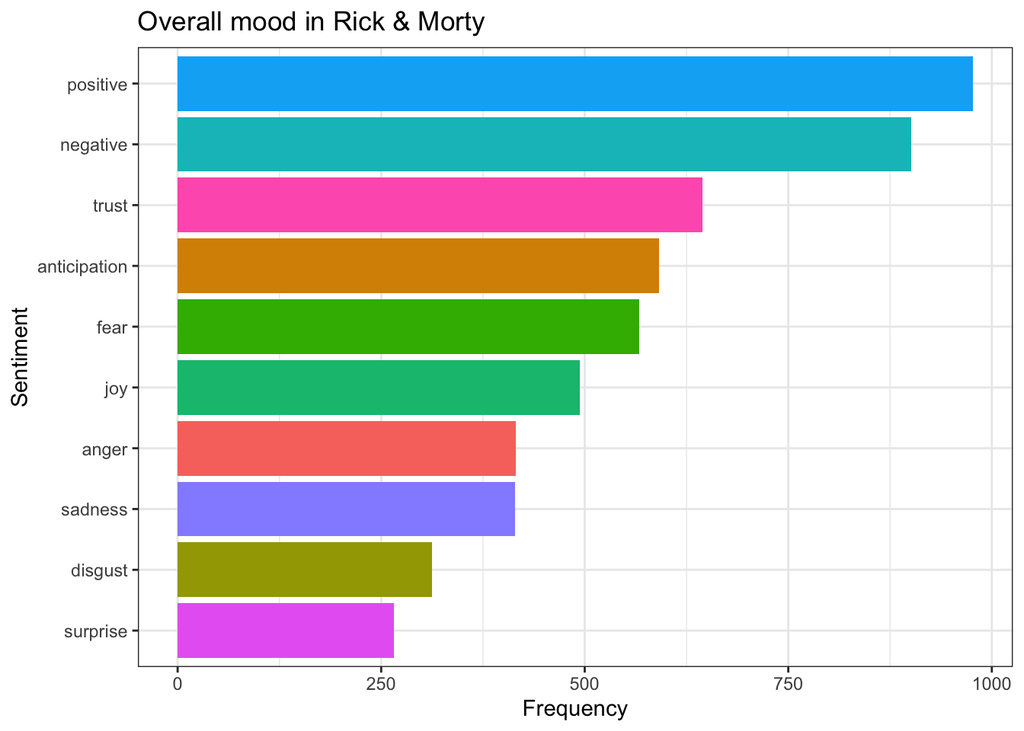

```r
sentiments %>%
  ggplot(aes(x=reorder(sentiment, n), y=n)) +
  geom_bar(stat="identity", aes(fill=sentiment), show.legend=F) +
  labs(x="Sentiment", y="Frequency", title="Overall mood in Rick & Morty") +
  coord_flip() +
  theme_bw()
```

##### For each of the ten sentiments, which words are said the most in r&m?

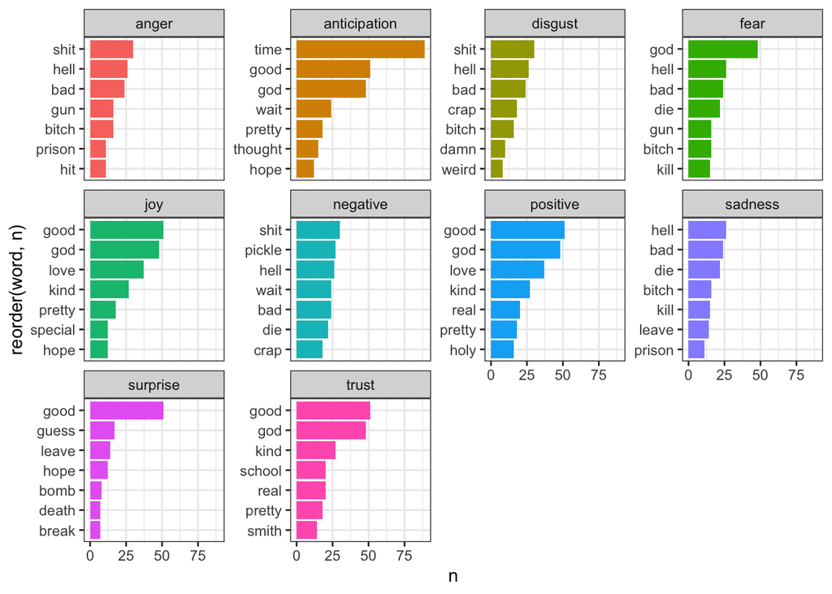

```r
tokens %>%
  inner_join(nrc, "word") %>%
  count(sentiment, word, sort=T) %>%
  group_by(sentiment) %>%
  arrange(desc(n)) %>%
  slice(1:7) %>%

  ggplot(aes(x=reorder(word, n), y=n)) +
  geom_col(aes(fill=sentiment), show.legend = F) +
  facet_wrap(~sentiment, scales = "free_y") +
  coord_flip() +
  theme_bw()
```

##### Same as above, but grouping by character and showing sentiment frequency

[figure not shown]

```r
tokens %>%
  filter(name %in% c("Rick","Morty","Beth","Jerry","Summer")) %>%
  inner_join(nrc, "word") %>%
  count(name, sentiment, sort=T) %>%

  ggplot(aes(x=sentiment, y=n)) +
  geom_col(aes(fill=sentiment), show.legend = F) +
  facet_wrap(~name, scales="free_x") +
  labs(x="Sentiment", y="Frequency", title="Character Moods") +
  coord_flip() +
  theme_bw()
```